# Unit 2 Module 2a

Spatial Data Analysis with R (01:450:320)

# 1 Working with raster data

We are now going to start working with the `terra` package. `terra` is newer and faster version of the older `raster` package, per the help (`?terra`):

> The terra package is conceived as a replacement of the raster package. terra has a very similar, but simpler, interface, and it is faster than raster. At the bottom of this page there is a table that shows differences in the methods between the two packages.

`terra` is somewhat conversant with the tidyverse and `sf`, but it has its own vector class (`vec`) that we will have to use for some operations. The upshot of this is that operations involving raster-vector interactions will sometimes require coercion of `sf` to `vec` objects. That is not a major obstacle, however.

The material in this section assumes that the reader is familiar with standard raster GIS operations and concepts, ranging from projections and transformations to moving windows, raster algebra, terrain analysis, and the like.

We’ll use the following datasets in this section:

```r
library(sdadata)
sf_use_s2(FALSE) # a trick for many spatial issues

species <- system.file("extdata/species.csv", package = "sdadata") %>%
  read_csv(show_col_types = FALSE)
roads <- system.file("extdata/roads.geojson", package = "sdadata") %>% st_read
districts <- system.file("extdata/districts.geojson", package = "sdadata") %>%
  st_read
```

# 2 raster basics

## 2.1 SpatRaster* classes

We’ll start off by learning about the basic classes associated with rasters generated by the `terra` package, which we will do by building our own objects from scratch, starting with a `SpatRaster`

### 2.1.1 RasterLayer

```r
# Chunk 1
# #1
e <- ext(c("xmin" = 34, "xmax" = 36, "ymin" = -6, "ymax" = -4))
#
# #2
r <- rast(x = e, res = 0.25, crs = crs(districts))
#
# #3
set.seed(1)
values(r) <- sample(1:100, size = ncell(r), replace = TRUE)  # 3
# r[] <- sample(1:100, size = ncell(r), replace = TRUE)
# r <- setValues(x = r, values = sample(1:100, size = ncell(r), replace = TRUE))
```

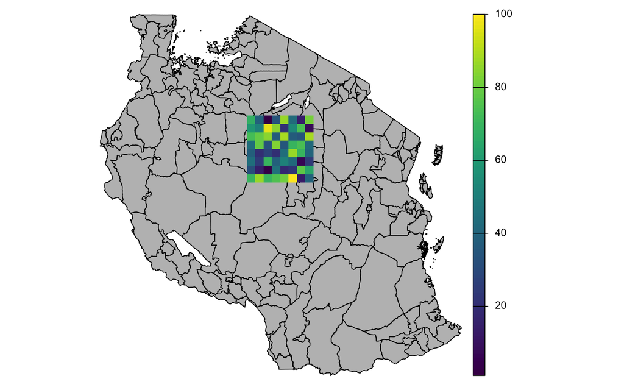

```r
par(mar = c(0, 0, 0, 4))
plot(st_geometry(districts), col = "grey", reset = FALSE)
plot(r, add = TRUE, ext = ext(districts))
```

We just used several functions from the `terra` package to create a random `SpatRaster` named `r` that has a 1/4 degree resolution and covers an area of 2 X 2 degrees in centural Tanzania. This particular raster is a temporary one that lives in memory.

> filename (character), missing, SpatRaster, SpatRasterDataset, SpatExtent, SpatVector, matrix, array, list of SpatRaster objects. For other types it will be attempted to create a SpatRaster via (‘as(x, “SpatRaster”)’

Line # 2 creates an empty raster `r` with no cell values, so in # 3 we assign some randomly selected values into `r`. Note the method of assignment, using the `values` function; there are two other lines commented out below # 3 that show different ways of doing the same job.

The plot of `r` over `districts` uses the `plot` method defined for `raster*` objects. Note that it automatically creates a continuous legend, and also note that `terra::plot` can work with `sf::plot`. The plot is not very nice.

Let’s look now at the structure of the object `r`.

```r
# Chunk 2
r
```

```
#> class       : SpatRaster
#> size        : 8, 8, 1  (nrow, ncol, nlyr)
#> resolution  : 0.25, 0.25  (x, y)
#> extent      : 34, 36, -6, -4  (xmin, xmax, ymin, ymax)
#> coord. ref. : lon/lat WGS 84 (EPSG:4326)
#> source(s)   : memory
#> name        : lyr.1
#> min value   :     1
#> max value   :   100
```

```r
class(r)
```

```
#> [1] "SpatRaster"
#> attr(,"package")
#> [1] "terra"
```

```r
typeof(r)
```

```
#> [1] "S4"
```

```r
slotNames(r)
```

```
#> [1] "pntr"
```

```r
r@pntr
```

```
#> C++ object <0xb36536840> of class 'SpatRaster' <0xb34b9e700>
```

```r
names(r@pntr)
```

```
#>  [1] "hasWindow"       "is_multidim"     "subset"          "range_max"       "hasCategories"
#>  [6] "finalize"        "extent"          "timestep"        "initialize"      "hasUnit"
#> [11] "names"           ".module"         "filenames"       "rgbtype"         "rgb"
#> [16] "dataType"        "setValueType"    ".cppclass"       "hasRange"        "ncol"
#> [21] "messages"        "hasColors"       "timezone"        "depth"           "origin"
#> [26] "nsrc"            "hasDepth"        ".self"           "inMemory"        "get_sourcenames"
#> [31] "has_error"       "time"            "has_warning"     "hasValues"       "isMD"
#> [36] "nlyr"            "range_min"       "valueType"       "get_crs"         "hasTime"
#> [41] ".pointer"        "nrow"            "setValues"       ".refClassDef"    "res"
#> [46] "units"
```

```r
res(r)
```

```
#> [1] 0.25 0.25
```

`r` is an S4 object that has only slot `pntr`, which is actually from C++ (`terra` is written in C++ and creates a C++ object). There are a number of slots in there, which we can see by running `names(r@pntr)`, but the `terra` packages provides methods for accessing those (e.g. `ext()` to get extent; `sources()` to get the raster’s filename, if written to disk; `values()` gets access to the data in the raster).

### 2.1.2 From 2- to 3-D

We have just seen how to create a `SpatLayer` and learned a bit about the structure of this kind of object, which is two-dimensional. We are now going to learn about three-dimensional rasters. Let’s create some new data.

```r
# Chunk 3
r2 <- r > 50
r3 <- r
set.seed(1)
values(r3) <- rnorm(n = ncell(r3), mean = 10, sd = 2)
l <- list(r, r2, r3)
```

We used r to create two new rasters, `r2` and `r3`. `r2` was made by using a logical operator (`>`) to find the locations where `r`’s values exceed 50, creating a binary `SpatRaster` where 1 indicates the matching pixels, and 0 those that don’t. `r3` was made by using `r` as a template, then overwriting the values with numbers generated randomly from a normal distribution (`rnorm`). These were then combined into list `l`.

```r
# Chunk 4
s <- rast(l)
# s <- c(r, r2, r3)  # also works
names(s) <- c("r", "r2", "r3")
s
```

```
#> class       : SpatRaster
#> size        : 8, 8, 3  (nrow, ncol, nlyr)
#> resolution  : 0.25, 0.25  (x, y)
#> extent      : 34, 36, -6, -4  (xmin, xmax, ymin, ymax)
#> coord. ref. : lon/lat WGS 84 (EPSG:4326)
#> source(s)   : memory
#> names       :   r,    r2,       r3
#> min values  :   1, FALSE,  5.57060
#> max values  : 100,  TRUE, 14.80324
```

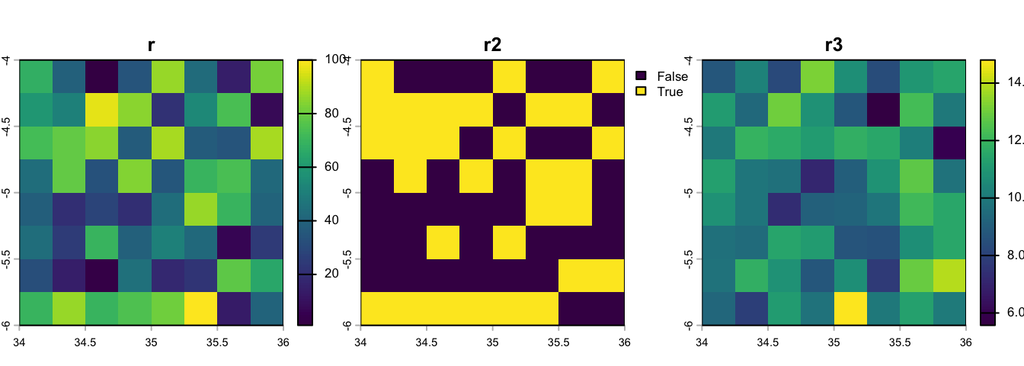

```r
plot(s, nr = 1)
```

In the preceding code blocks, we created a multi-layer `SpatRast` from `l`, which is a series of rasters that have the same extent and resolution, which are “stacked” on top of one another in the order that they are given in the input list. The stacked layers can come from rasters held in memory, or from any number of files stored in different areas on disk, or from a multi-layer raster held in a single file on disk.

Applying `plot` to a stack or brick results in the automatic plotting of each layer into its own sub-window, with coordinates along the plot axes. You can specify numbers of rows and columns in your plotting device using the “nc” and “nr” arguments to `terra::plot`.

Here’s a more informative (by putting it over a map of Tanzania) way of plotting the layers in `s`. Note the use of `ext` in the plot, which we use to make the raster plot extent by the same as `districts`, to force the plot outside of `district` extent (this doesn’t work for the logical raster, however):

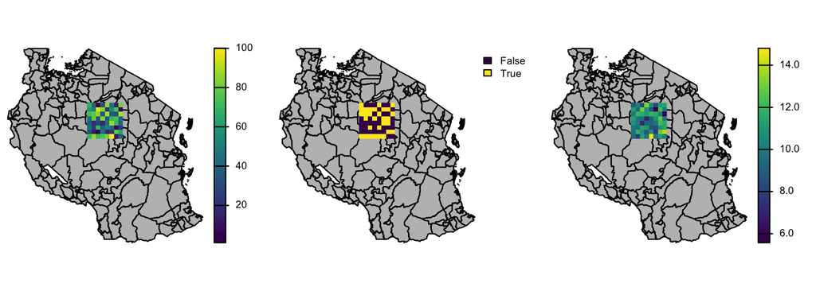

```r
# Chunk 5
par(mfrow = c(1, 3), mar = c(0, 0, 0, 4))
for(i in 1:nlyr(s)) {
  districts %>% st_geometry %>% plot(col = "grey")
  plot(s[[i]], add = TRUE, ext = ext(districts))
}
```

## 2.2 Reading and writing rasters

So far we have used `SpatRaster`s that are held in memory. Let’s write these out onto disk and then read them back in. Although we are creating a temporary directory for these in the code below, you should write these to your `notebooks/data` folder (per instructions in Unit 2 module 1 vignette.

```r
# Chunk 6
# #1 - write to disk
writeRaster(r, filename = file.path(tempdir(), "r.tif"))
writeRaster(r2, filename = file.path(tempdir(), "r2.tif"))
writeRaster(r3, filename = file.path(tempdir(), "r3.tif"))
writeRaster(s, filename = file.path(tempdir(), "s.tif"))

# #2 - read back in each individual raster and recreate stack
r <- rast(file.path(tempdir(), "r.tif"))
r2 <- rast(file.path(tempdir(), "r2.tif"))
r3 <- rast(file.path(tempdir(), "r3.tif"))
s <- c(r, r2, r3)  # recreate stack

# #3 - programmatic creation of stack
fs <- dir(tempdir(), pattern = "r.*.tif", full.names = TRUE)
s <- rast(lapply(fs, rast))
# s <- fs %>% lapply(rast) %>% rast  # pipeline approach works, too

# #4 - read in single geotiff "brick"
b <- rast(file.path(tempdir(), "s.tif"))
```

In #1 above, we use `writeRaster` to write out each of the three individual rasters to a geotiff, and write `s` to a three-band geotiff. In #2 we use the `rast` function to read back in the individual rasters, and then recreate stack `s` from those. #3 is a more programmatic way of doing #2, using the `dir` function to read the directory, looking for filenames matching a pattern, and returning the full paths to the matching files. These paths are then used in an `lapply` to read the files in with `rast`, recreating list `l`, which is then stacked. The pipeline approach that wraps up these commands in one line is shown commented out below that.

Blocks #2 and #3 illustrate how `rast` can be used to create a three-dimensional grid from different files, which differ from what you see next in #4, where the “s.tif” is read from a single geotiff “brick”. Note the terms we are using here, “stack” and “brick”, are leftovers from two separate classes (`RasterStack` and `RasterBrick`) that had separate functions (`stack` and `brick`) under the forerunner `raster` package, which were designed to separately handle the case of combining multiple separate files on disk or reading from or writing to single multi-layer files. `terra` only has the single `SpatRast` class and `rast` function now, which handles all cases.

## 2.3 From vector to raster and back again

Now that you know the `SpatRaster` class, and how to read and write it to disk, let’s figure out how to change between raster and vector types.

### 2.3.1 Vector to raster

We have several vector datasets that come with `sdadata` which we can rasterize, starting with the district boundaries.

```r
# Chunk 7
# #1
tzar <- rast(x = ext(districts), crs = crs(districts), res = 0.1)
values(tzar) <- 1:ncell(tzar)
#
# #2
districts <- districts %>% mutate(ID = 1:nrow(.))
distsr <- districts %>%
  rasterize(x = ., y = tzar, field = "ID") %>%
  print()
```

```
#> class       : SpatRaster
#> size        : 108, 109, 1  (nrow, ncol, nlyr)
#> resolution  : 0.09958904, 0.09980746  (x, y)
#> extent      : 29.58953, 40.44473, -11.76235, -0.983143  (xmin, xmax, ymin, ymax)
#> coord. ref. : lon/lat WGS 84 (EPSG:4326)
#> source(s)   : memory
#> name        :  ID
#> min value   :   1
#> max value   : 170
```

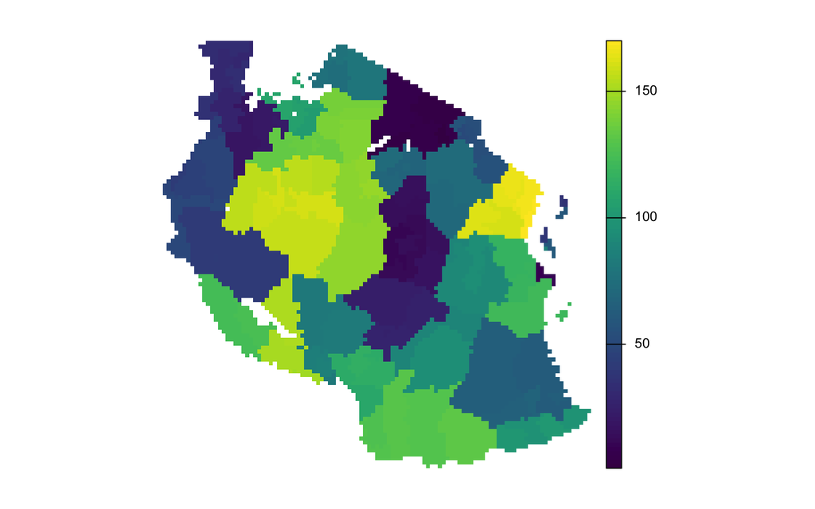

```r
par(mar = c(0, 0, 0, 4))
plot(distsr, axes = FALSE)
```

In #1, we took an initial step to define a raster (`tzar`) that has the properties of resolution (0.1 decimal degrees), CRS, and extent that we want our rasterized vector to have. We set the extent of this raster to that of `districts`, using `extent` to get the bounding box coordinates (`extent` retrieves the same parameters as `sf::st_bbox`, but the output is in a different format).

Our plot removes the coordinate-labelled axes and box that otherwise drawn around raster plots by default.

Next we rasterize the `species` dataset, which requires a little more prep to be meaningful:

```r
# Chunk 8
# #1
tzar2 <- rast(x = ext(districts), crs = crs(districts), res = 0.25)
values(tzar2) <- 1:ncell(tzar2)

# #2
speciesr <- species %>%
  dplyr::select(x, y) %>%
  mutate(count = 1) %>%
  st_as_sf(coords = c("x", "y"), crs = 4326) %>%
  rasterize(x = ., y = tzar2, field = "count", fun = sum) %>%
  print()
```

```
#> class       : SpatRaster
#> size        : 43, 43, 1  (nrow, ncol, nlyr)
#> resolution  : 0.2524466, 0.2506792  (x, y)
#> extent      : 29.58953, 40.44473, -11.76235, -0.983143  (xmin, xmax, ymin, ymax)
#> coord. ref. : lon/lat WGS 84 (EPSG:4326)
#> source(s)   : memory
#> name        :  sum
#> min value   :    1
#> max value   : 1216
```

```r
# #3
par(mar = c(0, 0, 1, 4))
districts %>%
  st_union %>%
  plot(col = "grey", border = "grey",
       main = expression(paste("N species per 0.25", degree, " cell")))
```

```
#> although coordinates are longitude/latitude, st_union assumes that they are planar
```

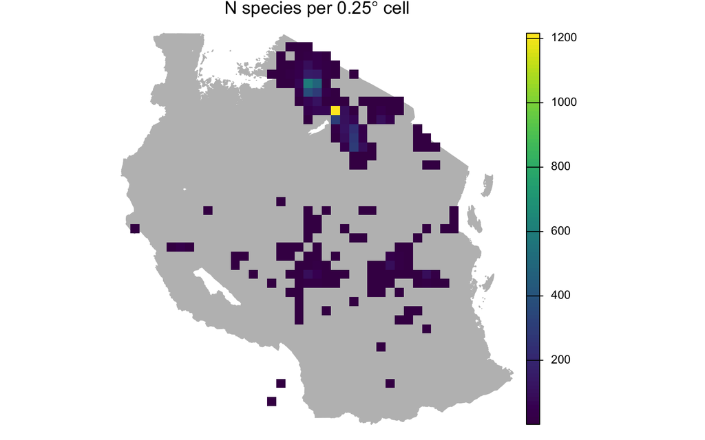

[output not shown]

```r
plot(speciesr, add = TRUE, axes = FALSE)
```

In #2, we do the rasterization as part of a pipeline. The first two lines prepare the `species` dataset. We add a new `count` variable (which assigns a value of 1 to each species record) before converting species to `sf` in the third line. We then `rasterize` the *count* variable, using the `sum` function to aggregate the number of species per 0.25$\circ$ grid cell.

The resulting plot (#3) shows that most cells have less than 20 species. We add an extra plot decoration step, using `expression` with `paste` to add a superscript degree symbol to our plot title.

```r
# Chunk 9
roadsr <- roads %>%
  filter(as.numeric(st_length(.)) > 50000) %>%
  mutate(ID = 1:nrow(.)) %>%
  st_transform(crs = 4326) %>%
  rasterize(., tzar, field = "ID")
```

### 2.3.2 Raster to vector

`terra` gives us functions that allow us to transform rasters to vectors, in this case `terra`’s native vector class, `SpatVector`, which we can further coerce to `sf`

```r
# Chunk 10
# #1
dists_fromr <- as.polygons(x = distsr, dissolve = TRUE) %>%
  print()
```

```
#>  class       : SpatVector
#>  geometry    : polygons
#>  dimensions  : 169, 1  (geometries, attributes)
#>  extent      : 29.58953, 40.44473, -11.76235, -0.983143  (xmin, xmax, ymin, ymax)
#>  coord. ref. : lon/lat WGS 84 (EPSG:4326)
#>  names       :    ID
#>  type        : <int>
#>  values      :     1
#>                    2
#>                    3
```

```r
dists_fromr <- st_as_sf(dists_fromr) %>% print()
```

```
#> Simple feature collection with 169 features and 1 field
#> Geometry type: GEOMETRY
#> Dimension:     XY
#> Bounding box:  xmin: 29.58953 ymin: -11.76235 xmax: 40.44473 ymax: -0.983143
#> Geodetic CRS:  WGS 84
#> First 10 features:
#>    ID                       geometry
#> 1   1 MULTIPOLYGON (((36.66035 -3...
#> 2   2 POLYGON ((36.56076 -3.37852...
#> 3   3 MULTIPOLYGON (((35.86364 -3...
#> 4   4 POLYGON ((36.16241 -2.28064...
#> 5   5 POLYGON ((36.75994 -3.0791,...
#> 6   6 POLYGON ((35.96323 -2.77967...
#> 7   7 POLYGON ((35.2661 -1.681795...
#> 8   8 POLYGON ((39.15008 -6.77197...
#> 9   9 POLYGON ((39.05049 -6.57236...
#> 10 10 POLYGON ((39.24967 -6.87178...
```

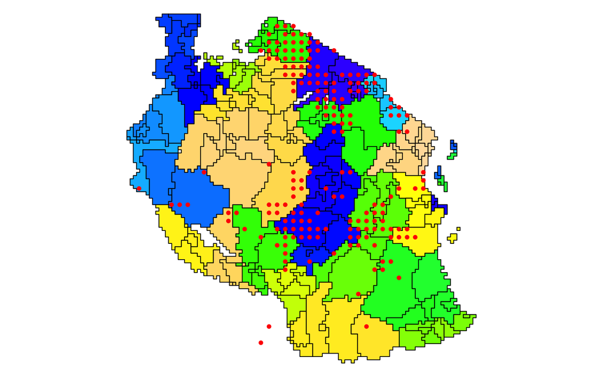

```r
# #2
species_fromr <- as.points(x = speciesr) %>%
  st_as_sf

par(mar = c(0, 0, 0, 0))
dists_fromr %>%
  st_geometry %>%
  plot(col = topo.colors(n = nrow(districts)))
species_fromr %>%
  plot(pch = 20, col = "red", add = TRUE)
```

Vectorizing rasters and then vectorizing back again means that you end up with lower resolution vectors if the raster is fairly coarse. You will note that this has occurred here, both in converting the rasterized districts back to polygons (#1) and the rasterized species counts back to points (#2). There are several things to note here. First, we used different functions for vectorizing polygons and points. Second, we piped each vectorization output to `st_as_sf`, because the endresult of the `as.polygons`/`as.points` functions is a `SpatVector` object, so the extra step coerces those to `sf`.

## 2.4 Projections

Up until now, our `SpatRaster` data have been in geographic coordinates systems. Let’s transform these to projected coordinates, using the rasterized districts as an example.

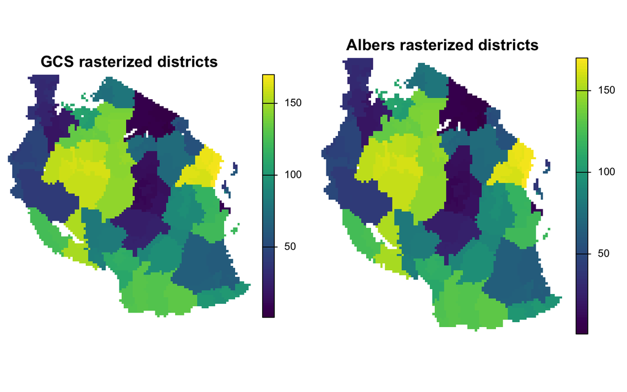

```r
# Chunk 11
# #1
tzar_alb <- project(x = tzar, y = crs(roads), res = 11000, method = "near")

# #2
distsr_alb <- project(x = distsr, y = tzar_alb, method = "near")

par(mfrow = c(1, 2), mar = c(1, 0.5, 1, 4))
plot(distsr, main = "GCS rasterized districts", axes = FALSE, mar = NA)
plot(distsr_alb, main = "Albers rasterized districts", axes = FALSE, mar = NA)
```

In our first step (#1), we apply `project` to our `tzar` object, transforming it to the Albers projection used by `roads` (the “y” argument). We define an output “res” of 11,000 m, or 11 km, which is reasonably close to the 1/10th of a degree resolution of `tzar`. We also choose a “method” for calculating the transformed values in the new raster. In this case, since `tzar` has values that are basically an integer index of grid cells, we use the “near” (nearest neighbor) option, to avoid the bilinear interpolation that would occur by default (see `?project`).

The result, `tzar_alb`, then becomes a reference raster (i.e. the raster defining the parameters) for other rasters that need to be reprojected, which is how we use it when reprojecting `distsr_alb` (# 2). In this case, we pass `tzar_alb` to the “y” argument, and don’t need the “res” argument or to specify a CRS (because the function reads those values from “tzar_alb”). Here we again use the “near” method so that we do not change the values of the categorical identifier of each district. You can see how the interpolation choice matters in the plot below, which compares the bilinear to nearest neighbor method–see how the bilinear approach changes values along district boundaries?

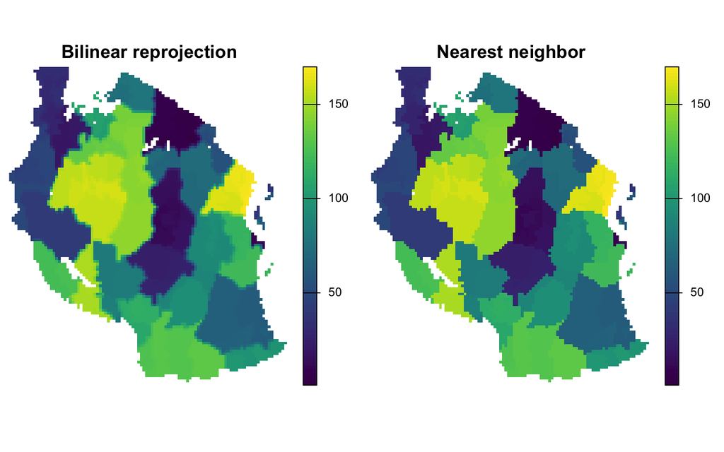

```r
# Chunk 12
distsr_alb2 <- project(x = distsr, y = tzar_alb, method = "bilinear")

par(mfrow = c(1, 2), mar = c(1, 0.5, 1, 4))
plot(distsr_alb2, main = "Bilinear reprojection", axes = FALSE, mar = NA)
plot(distsr_alb, main = "Nearest neighbor", axes = FALSE, mar = NA)
```

A bilinear interpolation is more appropriate for a raster of continuous values, or one where it makes sense to have values averaged during the reprojection process, such as the `speciesr` dataset.

## 2.5 Practice

### 2.5.1 Questions

1. What is a primary difference between `sf` and `s4` object classes?
2. What function should you use to read and write a multi-layer raster?
3. What class of object do `terra`’s vectorization functions produce?

### 2.5.2 Code

1. Create a new raster `r4`, using `r3` (above) as a template. Update the values of `r4` using numbers randomly selected from a uniform distribution ranging between 0 and 1. Create another raster `r5` by finding the values greater than 0.5 in r4. Recreate the list `l` with `r`, `r2`, `r3`, `r4`, and `r5`, and then create and plot stack `s2`.
2. Create a new brick `b2` by applying the `rast` function to write `s2` and to disk as `b2.tif`, specifying the path to your `notebooks/data` folder.
3. Following the steps in Chunk 8, recreate `speciesr` by re-rasterizing `species` at a 0.2 degree resolution. Plot the result.
4. Project the new 0.2 degree resolution `speciesr` to an Albers projection with a target resolution of 20 km (20,000 m), calling it `speciesr_alb`. Chunk 11 is your guide, but reproject using a bilinear rather than nearest neighbor interpolation (see `?project`). Make a two panel plot comparing `speciesr` on the left, plotted over the unioned districts of Tanzania in grey, with `speciesr_alb` on the right, plotted over the unioned districts of Tanzania in grey (and transformed to Albers). Code in Chunks 8 and 11 can help.
5. Convert `distsr` to an `sf` polygons object, using `as.polygons`. Plot the result without coercing to `st_geometry`.

# 3 Pre-processing and local to global statistics

This unit starts to focus on some of the analyses you can do with raster data, focusing specifically on calculating statistics from rasters. We will start in on that after doing a bit more raster processing and preparation.

## 3.1 Pre-processing

We will keep working with the data from the previous sections, adding in a new dataset that loads with `sdadata`, `bioclim`.

```r
# Chunk 13
bioclim <- rast(system.file("extdata/bioclim.tif", package = "sdadata"))
```

Since we are recycling some of the objects from the previous section but you might have cleared your workspace, here is code that will allow you to quickly rebuild the datasets we will use in this next section, without having to hunt back through the previous section to find it.

```r
tzar <- rast(x = ext(districts), crs = crs(districts), res = 0.1)
values(tzar) <- 1:ncell(tzar)

distsr <- system.file("extdata/districts.geojson", package = "sdadata") %>%
  st_read %>%
  mutate(ID = 1:nrow(.)) %>%
  rasterize(x = ., y = tzar, field = "ID")

tzar2 <- rast(x = ext(districts), crs = crs(districts), res = 0.25)
speciesr <- system.file("extdata/species.csv", package = "sdadata") %>%
  read_csv() %>%
  dplyr::select(x, y) %>% mutate(count = 1) %>%
  st_as_sf(coords = c("x", "y"), crs = 4326) %>%
  rasterize(x = ., y = tzar2, field = "count", fun = sum)
```

There a few important things we missed doing in the first section. But first let’s talk about the new data we just loaded, `bioclim`. We have a help file in `sdadata` describing the dataset, which provides 19 bioclimatic variables at ~1 km resolution, representing annual trends, seasonality, and extreme environmental factors. These variables are derived from downscaled model output (CHELSA) and are corrected by weather station observations. The bioclimatic layers characterize long-term climatological baselines that are biologically meaningful (read more about them [here](https://www.chelsa-climate.org/datasets/chelsa_bioclim)), and we have included the full suite of variables subset over Tanzania.

```r
# Chunk 14
bioclim
```

```
#> class       : SpatRaster
#> size        : 1293, 1302, 19  (nrow, ncol, nlyr)
#> resolution  : 0.008333333, 0.008333333  (x, y)
#> extent      : 29.59153, 40.44153, -11.75847, -0.9834726  (xmin, xmax, ymin, ymax)
#> coord. ref. : lon/lat WGS 84 (EPSG:4326)
#> source      : bioclim.tif
#> names       : bio01, bio02, bio03, bio04, bio05,  bio06, ...
#> min values  : -6.65,   0.8, 0.224,  18.8, -0.25, -14.45, ...
#> max values  : 28.65,  13.0, 0.921, 240.1, 36.35,  24.05, ...
```

```r
names(bioclim)
```

```
#>  [1] "bio01" "bio02" "bio03" "bio04" "bio05" "bio06" "bio07" "bio08" "bio09" "bio10" "bio11" "bio12"
#> [13] "bio13" "bio14" "bio15" "bio16" "bio17" "bio18" "bio19"
```

That tells us a bit more about the `bioclim` subset that we have, including the names for each layer, which correspond to the 19 bioclimatic variables in the series.

Let’s have a look at a few of the variables in `bioclim`:

- Mean Annual Near-Surface Air Temperature (bio01)
- Mean Diurnal Near-Surface Air Temperature Range (bio02)
- Isothermality (bio03)

```
#> although coordinates are longitude/latitude, st_union assumes that they are planar
#> although coordinates are longitude/latitude, st_union assumes that they are planar
#> although coordinates are longitude/latitude, st_union assumes that they are planar
```

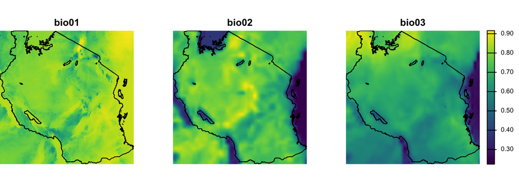

```r
# Chunk 15
par(mfrow = c(1, 3), mar = c(0, 0, 1, 4))
for(i in 1:3) {
  leg <- ifelse(i == 3, yes = TRUE, no = FALSE)  # 1
  plot(bioclim[[i]], main = names(bioclim)[[i]], axes = FALSE,
       zlim = c(0, max(bioclim[1:3])), legend = leg, mar = NA)  # 2
  plot(st_union(districts), add = TRUE)
}
```

The second thing: we haven’t discussed this yet, but you will see in the example above that indexing into a `SpatRaster` to select a particular layer or layers is achieved through `[[]]`. This applies to both single (`[[x]]`) and multiple/recursive (`[[x:y]]`) indexing, which differs from indexing into a `list`, where you use `[x:y]` for multiple selection. Selection by layer names also works (`bioclim[[c("bio1", "bio12")]]`; `bioclim[["bio3"]]`)

### 3.1.1 Masking

We are interested in the bioclimatic data within Tanzania’s borders, so we need to mask out the values of `bioclim` that fall outside of Tanzania:

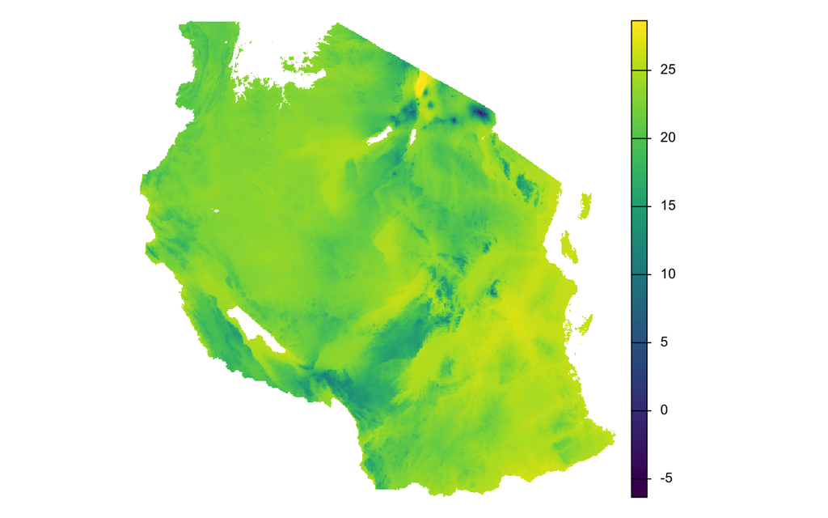

```r
# Chunk 16
test_m <- mask(x = bioclim[[1]], mask = districts)
plot(test_m, axes = FALSE, mar = c(1, 0.5, 1, 4))
```

In the code above, we use the `districts` data to `mask` out the portions of `bioclim` (bio1) falling outside of Tanzania. Let’s apply that to the entire `bioclim` dataset:

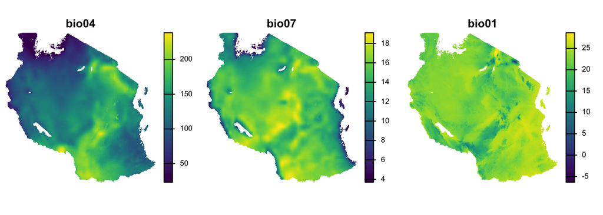

```r
# Chunk 17
bioclimz <- mask(x = bioclim, mask = districts)

set.seed(1)
ind <- sample(1:nlyr(bioclimz), size = 3)
plot(bioclimz[[ind]], axes = FALSE, nr = 1, mar = c(1, 0.5, 1, 4))
```

The new `bioclim` dataset contains all variables with the values outside of Tanzania converted to NA. The three plots are randomly selected from the layers of `bioclimz`, as a check to confirm that the masking was applied to all layers.

### 3.1.2 Cropping

If we need to chop a raster down to a smaller region, we can `crop` it. `crop` uses the extent of another object to achieve this.

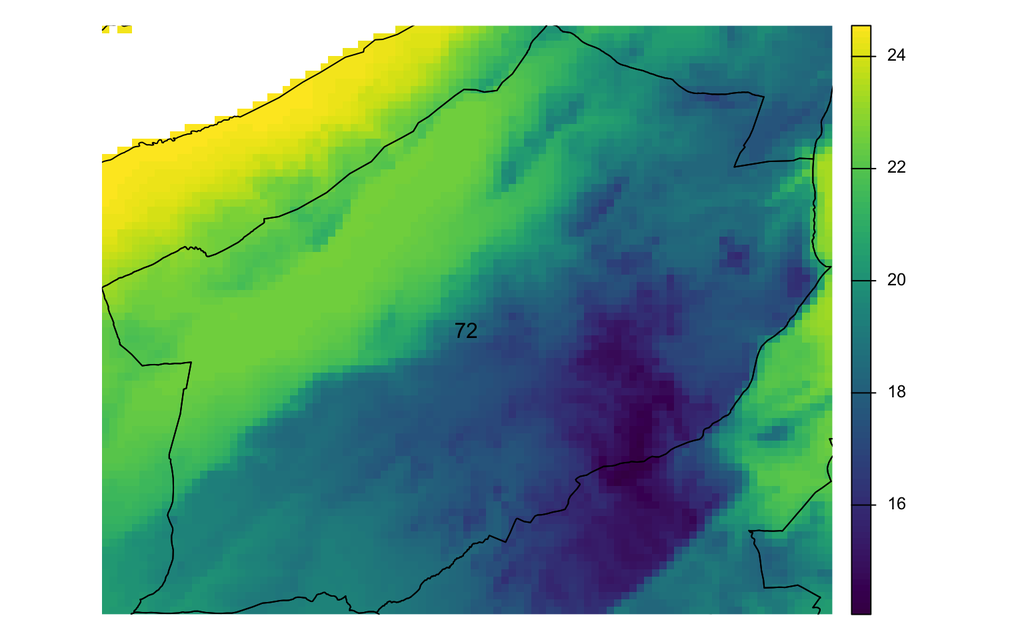

```r
# Chunk 18
bioclim1_dist72 <- crop(x = bioclimz[[1]], y = districts %>% slice(72))

plot(bioclim1_dist72, axes = FALSE, mar = c(1, 0.5, 1, 4))
plot(st_geometry(districts), add = TRUE)
districts %>%
  st_centroid %>%
  st_coordinates %>%
  text(x = ., labels = 1:nrow(.))
```

The above uses the extent of district 72 (`dist72`) to crop the first layer of `bioclimz`. Note that in the plotting step we can pipe the cropped raster to `plot`, and also that we can label the district numbers on the plot by extracting their centroid coordinates and passing these into the “x” argument of `text`, and then using the `nrow` of the piped-in data.frame of centroid coordinates as the labels.

Cropping is important if we want to confine further analyses to a particular sub-region. However, if we just want to focus our plot to a particular region, then we can simply zoom the plot to that region (without cropping) using an extent object.

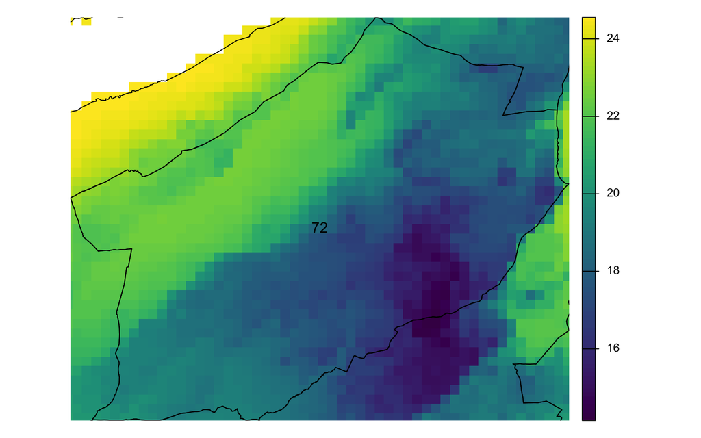

```r
# Chunk 19
plot(bioclimz[[1]], axes = FALSE, ext = ext(districts[72, ]),
     mar = c(1, 0.5, 1, 4))
plot(st_geometry(districts), add = TRUE)
districts %>%
  st_centroid %>%
  st_coordinates %>%
  text(x = ., labels = 1:nrow(.))
```

#### 3.1.2.1 A function-writing detour

As we write this, we find ourselves growing weary of repeatedly writing “axes = FALSE, box = FALSE” into the `plot` function, even with RStudio’s handy tab completion. This repeated use of the exact same code is the sort of situation that calls for writing your own function.

```r
# Chunk 20
plot_noaxes <- function(x, axes = FALSE, box = FALSE, mar = c(1, 0.5, 2, 4),
                        ...) {
  if(!class(x) %in%
     c("RasterLayer", "RasterStack", "RasterBrick", "SpatRaster")) {
    stop("This function is intended for rasters only", call. = FALSE)
  }
  par(mar = mar)
  if(class(x) %in% c("RasterLayer", "RasterStack", "RasterBrick")) {
    plot(x, axes = axes, box = axes, ...)
  } else {
    plot(x, axes = axes, mar = NA, ...)
  }
}
```

The function above (you can save it for your own usage) takes care of the axes and box problem by setting their default arguments to FALSE. It also sets the default plot margins to the ones we have mostly been using so far, and it checks whether the object being passed to it belongs to one of the raster classes (either from the older `raster` package or from `terra`), failing if it doesn’t. Otherwise, it retains all of the other functionality of `raster::plot` and `terra::plot`, and has the “…” argument, meaning you can pass other eligible arguments to it.

Let’s see how it works:

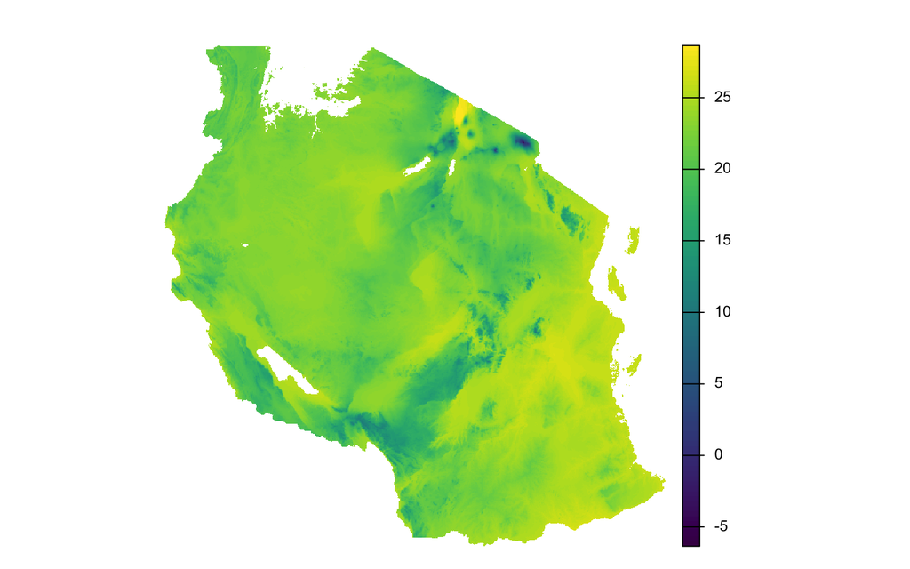

```r
# Chunk 21
# bioclimz[[1]] %>% plot_noaxes  # also works in a pipeline
plot_noaxes(bioclimz[[1]])
```

That will make plotting easier moving forward.

### 3.1.3 Aggregating/disaggregating

```r
# Chunk 21
bioclimz1agg <- aggregate(x = bioclimz[[1]], fact = 2, fun = mean)
bioclimz1agg
```

```
#> class       : SpatRaster
#> size        : 647, 651, 1  (nrow, ncol, nlyr)
#> resolution  : 0.01666667, 0.01666667  (x, y)
#> extent      : 29.59153, 40.44153, -11.76681, -0.9834726  (xmin, xmax, ymin, ymax)
#> coord. ref. : lon/lat WGS 84 (EPSG:4326)
#> source(s)   : memory
#> name        :  bio01
#> min value   : -6.075
#> max value   : 28.650
```

To disaggregate, there are two options:

```r
# Chunk 22
bioclimz1km <- disagg(x = bioclimz[[1]], fact = 5)
```

```
#> |---------|---------|---------|---------|==============
```

```r
# bioclimz1km <- disagg(x = bioclimz[[1]], fact = 5, method = "bilinear")
bioclimz1km
```

```
#> class       : SpatRaster
#> size        : 6465, 6510, 1  (nrow, ncol, nlyr)
#> resolution  : 0.001666667, 0.001666667  (x, y)
#> extent      : 29.59153, 40.44153, -11.75847, -0.9834726  (xmin, xmax, ymin, ymax)
#> coord. ref. : lon/lat WGS 84 (EPSG:4326)
#> source(s)   : memory
#> varname     : bioclim
#> name        : bio01
#> min value   : -6.65
#> max value   : 28.65
```

The second way (commented out), is to set `method = bilinear`, which interpolates during disaggregation. In this case, `disaggregate` does the job using the `resample` function, which we will see next.

### 3.1.4 Resampling

Resampling is done for many reasons, but one particularly common case is as a final step following aggregation or disaggregation, when it is needed to co-register the resulting grid to another grid.

```r
# Chunk 23
bioclim125 <- aggregate(x = bioclimz[[1]], fact = 5)  # no fun b/c default is mean
s <- c(bioclim125, speciesr)  # fails
```

```
#> Error:
#> ! [rast] extents do not match
```

```r
# Check their extent
ext(bioclim125)
```

```
#> SpatExtent : 29.59152693945, 40.46652689595, -11.77513920175, -0.983472578249996 (xmin, xmax, ymin, ymax)
```

```r
ext(speciesr)
```

```
#> SpatExtent : 29.5895292580001, 40.444734823, -11.7623492139999, -0.983143016999943 (xmin, xmax, ymin, ymax)
```

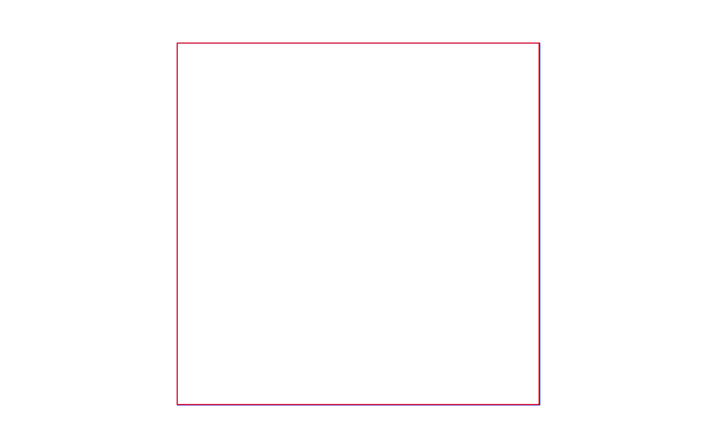

```r
# Very close, but not match exactly

par(mar = c(1, 1, 1, 1))
plot(ext(bioclim125), axes = FALSE, border = "blue")
plot(ext(speciesr), add = TRUE, border = "red")
```

After aggregating `bioclimz` layer 1, we try and fail to stack the result with `speciesr`, because (as the plot of extents show, and the warning tells) the two objects have different extents. So, another approach is needed:

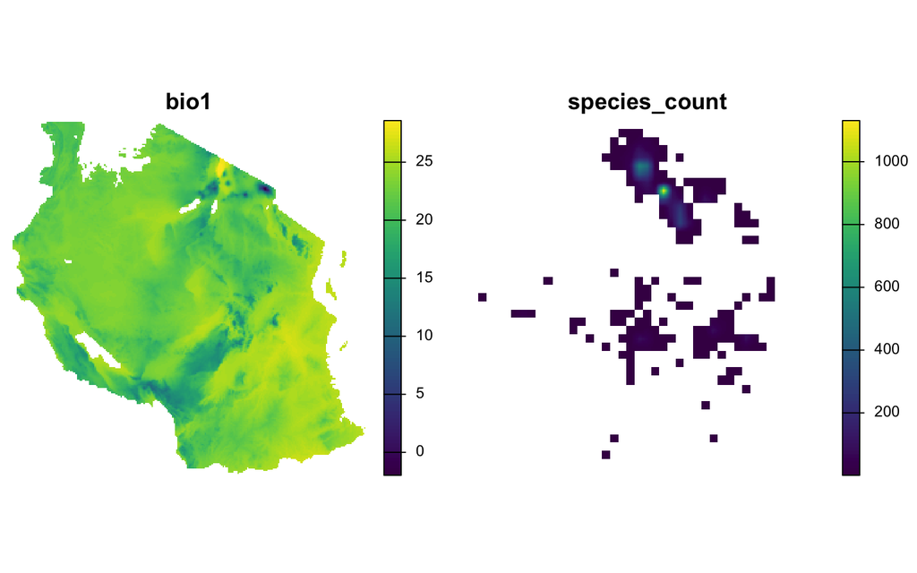

```r
# Chunk 24
speciesr_rs <- resample(x = speciesr, y = bioclim125)
s <- c(bioclim125, speciesr_rs)
names(s) <- c("bio1", "species_count")
plot_noaxes(s)
```

We resample `speciesr` to `bioclim125`, since `bioclim125` has the larger extent. However, there is one more thing we should do before using these data, and that is an adjustment to `speciesr`. Have a look at this:

```
#> although coordinates are longitude/latitude, st_union assumes that they are planar
```

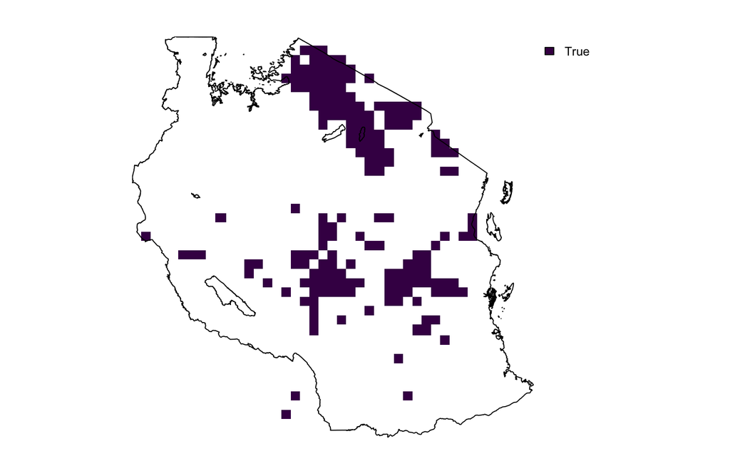

```r
plot_noaxes(s$species_count >= 0)
plot(st_geometry(st_union(districts)), add = TRUE)
```

This shows that there are no places where there are 0 species–because the original data contributing to `speciesr` (the second layer in `s`) was derived from point locations representing the approximate locations of where species were observed. The data thus have no points where there were 0 species observed, thus everywhere outside of observed locations is assigned a no data value. These are not analyzed in raster operations. So we have to fix this if we want to have the full area of Tanzania in the second layer of our stack.

```
#> although coordinates are longitude/latitude, st_union assumes that they are planar
```

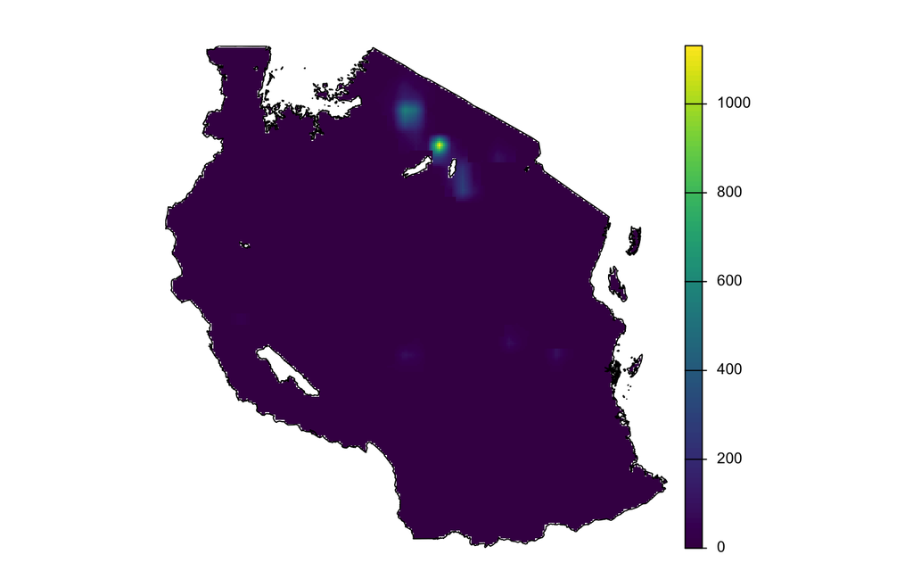

```r
s$species_count[is.na(s$species_count)] <- 0
s$species_count <- mask(s$species_count, s$bio1)
plot_noaxes(s$species_count)
plot(st_geometry(st_union(districts)), add = TRUE)
```

Now all the areas in `s$species_count` where no species were conducted area set to 0.

We can then stack and perform subsequent analyses that draw on both layers, e.g. finding areas where annual mean temperature exceeded 15 degree and where there was more than 1 species:

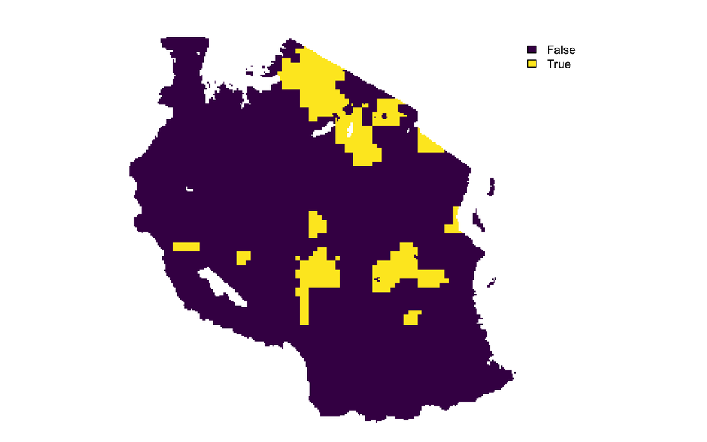

```r
# Chunk 25
plot_noaxes(s$species_count > 1 & s$bio1 > 15)
```

```r
# (s$bio1 > 15 & s$species_count > 1) %>% plot_noaxes  # also works
```

## 3.2 Analyses

Let’s move on now to some analyses with raster data.

### 3.2.1 Global statistics

The most basic analyses to perform on rasters is to calculate global summary statistics, i.e. statistics calculated across all cell values:

```r
# Chunk 26
global(x = bioclimz[[1]], stat = "mean", na.rm = TRUE)  # for a single variable

global(x = bioclimz[[c(5, 7, 14)]], stat = "mean", na.rm = TRUE)

summary(bioclimz[[1:3]])
```

[output not shown]

`global` lets you calculate specific statistics from the cell values of a lone `SpatRaster`, or for a single, multiple, or all layers in a `SpatRaster` layer. `summary` (a generic) returns the quantile values and counts the number of `NA` or no data cells. Both functions by default remove NA values (which are in many if not most rasters), which is something that usually has to be specified when trying to apply these statistical functions to an ordinary vector, e.g.

```r
# Chunk 27
v <- values(bioclimz[[1]])
mean(v)
```

```
#> [1] NA
```

```r
mean(v, na.rm = TRUE)
```

```
#> [1] 22.43886
```

`v` is a vector of all of the values from the first layer in the bioclim brick, including its NA values. `mean` returns an `NA` if you don’t tell the function to remove `NA` values first. This is important to remember, because both spatial and non-spatial data often have missing values, so you will have to deal with them explicitly in many cases.

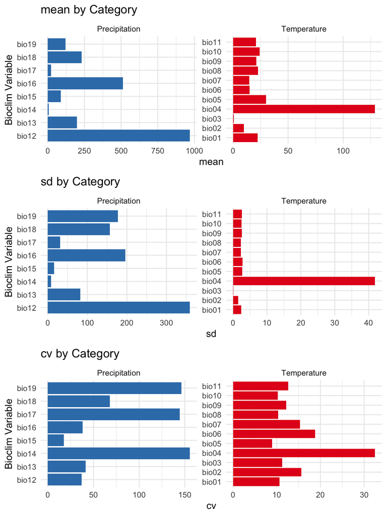

```r
# Chunk 28
# #1
cv <- function(x, na.rm) {
  cv <- sd(x, na.rm = na.rm) / mean(x, na.rm = na.rm) * 100
  return(cv)
}
bioclim_stats <- lapply(list(mean, sd, cv), function(x) {
  global(x = bioclimz, fun = eval(x), na.rm = TRUE)
})
names(bioclim_stats) <- c("mean", "sd", "cv")

# #2
bioclim_statsf <- do.call(cbind, bioclim_stats) %>% data.frame %>%
    mutate(var = row.names(.)) %>%
    rename(cv = global) %>%
    mutate(type = ifelse(as.numeric(gsub("bio", "", var)) <= 11,
                         "Temperature", "Precipitation"))

# #3
ps <- lapply(c("mean", "sd", "cv"), function(x) {
  ggplot(bioclim_statsf, aes(x = var, y = .data[[x]], fill = type)) +
    geom_col() +
    facet_wrap(~type, scales = "free") + # Separate scales for temp and precip
    coord_flip() +
    scale_fill_manual(values = c("Temperature" = "#e41a1c", "Precipitation" = "#377eb8")) +
    labs(x = "Bioclim Variable", y = x, title = paste(x, "by Category")) +
    theme_minimal() +
    theme(legend.position = "none")
})
cowplot::plot_grid(plotlist = ps, ncol = 1)
```

In #1 we use `lapply` to calculate 3 different statistics over all dates in `bioclimz`, meaning that we get a list for each statistic as calculated over all of Tanzania.

In #2, we use a pipeline to bind the summary vectors into a `data.frame` (one statistic per column), and then do some gymnastics to convert the row names of the `data.frame`, which are constructed from the layer names of `bioclimz` (which are stored as “bioXX”) to a vector of variables.

The results in the plots above reveal the long-term climatological structure of the landscape. The first panel shows the global mean for each layer, clearly illustrating the different scales between Temperature (BIO1–BIO11) and Precipitation (BIO12–BIO19) variables. The next two panels show two measures of spatial variability: the standard deviation (SD) and the coefficient of variation (CV). These measures summarize how much these climate factors vary across the geography of the study area.

For the temperature variables, the SD is generally low, except for BIO4 (Temperature Seasonality), which shows a distinct spike in spatial variation across the region. In the precipitation group, BIO12 (Annual Precipitation) shows a very high SD, which is expected as it tracks with the high mean values. However, the CV tells a more interesting story; while BIO12 has a high absolute variation (SD), its relative variation (CV) is actually lower than several other layers, such as BIO14 or BIO17. This indicates that while the total volume of rain varies, the most extreme spatial “patchiness” occurs during the driest periods of the year, where small local differences create significant relative spikes in variability.

Another way to summarize raster data is visually, using a histogram (`terra` has a generic `hist` function)

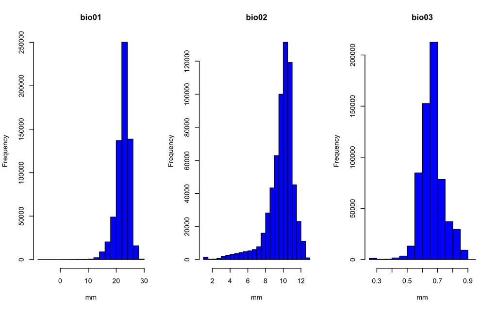

```r
# Chunk 30
par(mfrow = c(1, 3))
hist(bioclimz[[1:3]], col = "blue", xlab = "mm")
```

This variant plots a histogram per layer in the `SpatRaster` object (but we told it to plot 1 row, 3 columns, instead of the default (2 rows, 2 columns)).

`freq` is another way to summarize raster values that is similar to `hist` but without the automatic plot.

```r
# Chunk 31
f <- freq(bioclimz[[1]]) %>% print()
```

```
#>    layer value  count
#> 1      1    -7      3
#> 2      1    -6      6
#> 3      1    -5      4
#> 4      1    -4      3
#> 5      1    -3      7
#> 6      1    -2      7
#> 7      1    -1      9
#> 8      1     0     20
#> 9      1     1     35
#> 10     1     2     57
#> 11     1     3     58
#> 12     1     4     65
#> 13     1     5     72
#> 14     1     6     99
```

[output cut: 23 more lines]

Here we apply `freq` to a dataset with continuous values, although this function is probably best reserved for categorical rasters. However, it produces reasonable results here.

### 3.2.2 Local statistics

The previous section showed us how to produce statistics calculated across the entire raster. Now we will learn to calculate local, or neighborhood, statistics.

#### 3.2.2.1 Zonal

One way local statistics can be calculated is by defining zones and then calculating statistics within those zones.

```r
# Chunk 32
# #1
# zonemu <- zonal(x = bioclimz, z = distsr, fun = "mean")  # fails b/c extent

# #2
distsr_rs <- resample(x = distsr, y = bioclimz, method = "near")  # match extent
zonemu <- zonal(x = bioclimz, z = distsr_rs, fun = "mean", na.rm = TRUE)
head(zonemu)[, 1:5]
```

```
#>   ID    bio01     bio02     bio03    bio04
#> 1  1 18.82958 10.270139 0.6199528 183.5333
#> 2  2 20.62708 10.194445 0.6019861 202.8657
#> 3  3 21.61495  9.230065 0.6744109 145.4794
#> 4  4 21.91470 10.691425 0.6981019 126.3778
#> 5  5 19.40262 10.040972 0.6131875 183.4982
#> 6  6 21.86499 10.978851 0.6470662 179.5308
```

That creates a `data.frame` (truncated here to show the first 6 rows and 5 columns) of mean bioclim variables within each zone ( district), by date. The first attempt to run `zonal` (#1) would have failed because of mismatched extents (and therefore was commented out so it wouldn’t run), so we used `resample` in #2 to align extents before re-running `zonal`.

To map zonal statistics back onto their zones, we need to use another function, `subst`.

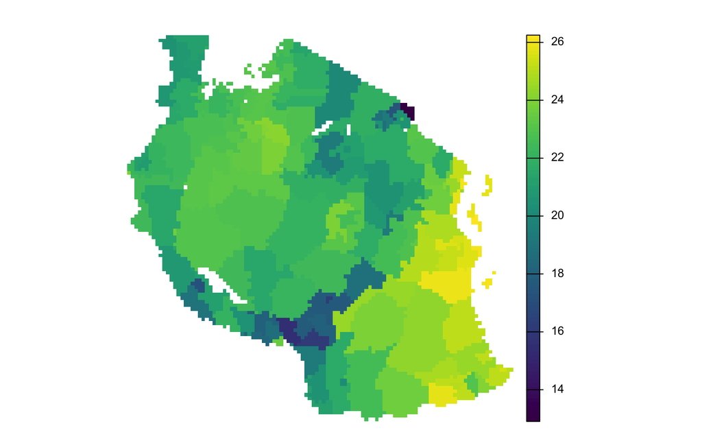

```r
# Chunk 33
subsmat <- zonemu %>% dplyr::select(1:2)
distr_rfmu <- subst(x = distsr_rs, from = subsmat[, 1], to = subsmat[, 2])
plot_noaxes(distr_rfmu)
```

`subst` replaces the values in a raster by other values contained within a `matrix` that correspond to a variable that has the same values as those in the raster (in this case the district IDs).

#### 3.2.2.2 Focal

Another way of calculating image statistics is to use a moving window/neighborhood approach. This is done with the `focal` function, which can be used to calculate a large number of different statistics. Here’s we’ll just show you the mean (also known as a low pass filter), with a few permutations to illustrate the concept. **Disclaimer:** This section assumes that you have applied moving window functions/low pass/high pass filters in your GIS/remote sensing classes so far, and thus are familiar with the calculations. If not, please be sure to ask about this in class.

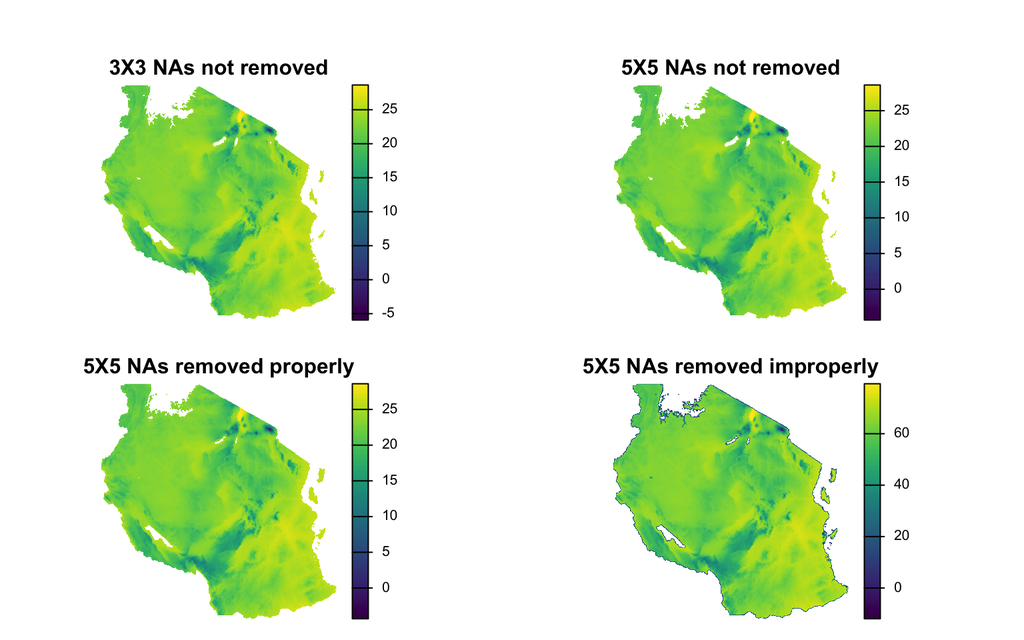

```r
# Chunk 34
# #1
wmat <- matrix(1 / 9, nrow = 3, ncol = 3)
bioclim1_focmu1 <- focal(x = bioclimz[[1]], w = wmat)

# #2
wmat <- matrix(1, nrow = 3, ncol = 3)
bioclim1_focmu2 <- focal(x = bioclimz[[1]], w = wmat, fun = mean)

# #3
wmat <- matrix(1, nrow = 5, ncol = 5)
bioclim1_focmu3 <- focal(x = bioclimz[[1]], w = wmat, fun = mean)

# #4
wmat <- matrix(1, nrow = 5, ncol = 5)
bioclim1_focmu4 <- focal(x = bioclimz[[1]], w = wmat, fun = mean, na.rm = TRUE)

# #5
wmat <- matrix(1 / 9, nrow = 5, ncol = 5)
bioclim1_focmu5 <- focal(x = bioclimz[[1]], w = wmat, na.rm = TRUE)

# plots
l <- list(bioclim1_focmu1, bioclim1_focmu3, bioclim1_focmu4, bioclim1_focmu5)
titles <- c("3X3 NAs not removed", "5X5 NAs not removed",
            "5X5 NAs removed properly", "5X5 NAs removed improperly")

# mar: c(bottom, left, top, right) - default is c(5, 4, 4, 2) + 0.1
# oma: outer margins - default is c(0, 0, 0, 0)
par(mar = c(4, 4, 2, 1), oma = c(0, 0, 2, 0), mfrow = c(2, 2))
for(i in 1:length(l)) {
  plot_noaxes(l[[i]], main = titles[i])
}
```

We have 5 variants above. In #1, we calculate the focal mean the recommended way, which is to:

- Define a matrix (`wmat`) that contains the weights that `focal` applies to each pixel when making neighborhood calculations. In this case, the matrix is 3X3, which is the size of our moving window, and the weights are distributed equally across all pixels and sum to 1 (each gets a weight of 1/9)
- `focal` then passes over each pixel, and multiplies those weights by each pixel value in the neighborhood, and then sums those to get the mean
- It sums the values because `sum` is the default value of the argument “fun” in the function `focal`, which is why we have not even specified the argument “fun” in Block 1

The code in #2 does the same thing. It passes the `mean` function to `focal`’s “fun” argument. The weights matrix in this case has 1s throughout; since we are not using the default “fun=sum” in `focal` and `mean` is doing the work, we can’t modify (by weighting) the pixel values if we want the correct mean. We also do not remove NA values from the calculation, so the results are nearly identical (and thus not plotted), except for very minor rounding issues (see section 1 of the [R Inferno](https://www.burns-stat.com/pages/Tutor/R_inferno_090109.pdf) for more about this).

In #4, we again pass `mean` to `focal`, and have a 5X5 neighborhood, but here we specify `na.rm = TRUE`, which means that focal passes `TRUE` to the “na.rm” argument of `mean`. This results in NAs being removed from each neighborhood before calculating the mean, thus boundary pixels are not lost (note the larger area left for water bodies). This is the correct way to remove NAs when calculating focal means.

### 3.2.3 Analyzing the Z dimension

If we have a `SpatRaster` with more than one layer, we have three dimensions (x, y, z). Often we want to analyze the values in the Z dimension (which may represent time, spectral bands, or unrelated spatial predictors in a model) without altering the x and y dimensions.

The workhorse for doing this sort of analysis is `app`, which allows you to apply pretty much any function to the Z-dimension of a multi-layer `SpatRaster`.

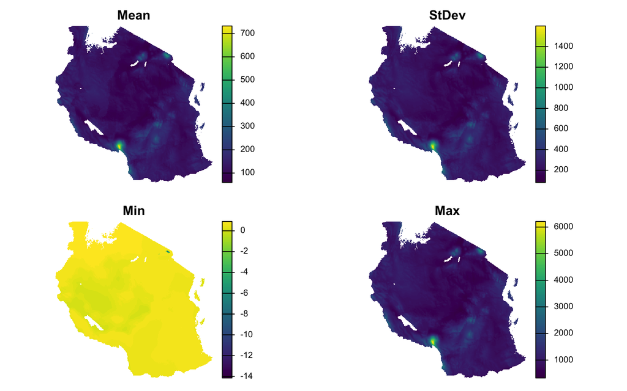

```r
# Chunk 35
# #1
bioclim_zmu <- app(x = bioclimz, fun = mean)
bioclim_zsd <- app(x = bioclimz, fun = sd)
bioclim_zrng <- app(x = bioclimz, fun = range)

# #2
bioclim_zstack <- c(bioclim_zmu, bioclim_zsd, bioclim_zrng)
names(bioclim_zstack) <- c("Mean", "StDev", "Min", "Max")

plot_noaxes(bioclim_zstack)
```

In #1 we pass `mean`, `sd`, and `range` to “fun” in `app`. Note that `range` always returns two values, so `app` conveniently returns a two-layer `SpatRaster` that contains the minimum in the first layer and the maximum in the second.

In #2 we then stack the three outputs, and rename the layers something meaningful so that `plot_noaxes` can plot them all at once.

## 3.3 Practice

### 3.3.1 Questions

1. How do `global`, `focal`, and `zonal` differ from one another?
2. How do you `disagg` a raster with interpolation?
3. How do you run `app` on images with different resolutions or extents?

### 3.3.2 Code

1. Sometimes we will use date for analysis. Run `as.Date("10-11-2017", "%m-%d-%Y")`, `as.Date("10-11-17", "%m-%d-%y")`, `as.Date("101117", "%m%d%y")`, and `as.Date("10112017", "%m%d%Y")` to get a better sense of date vectors work. Also try out `lubridate::mdy("10-11-2017")` and `lubridate::as_date("20171011")`.
2. Convert `species` to a 0.1 degree raster (`speciesr2`) that contains the count of species per grid cell. Use `distsr` as the target raster so that the extents align.
3. Use `zonal` on `speciesr2` to calculate the total number of species per district (use `distsr` to provide the zones), and then map them back onto the districts/zones using `subst`. Plot the result.
4. Use `focal` to calculate for `bioclimz[[12]]` the i) standard deviation within a 3X3 and 5X5 window, and ii) the maximum value in each 3X3 and 5X5 neighborhood. Do not remove NAs. Combine the results in a multi-layer `SpatRaster`, as above, and then plot them using `plot_noaxes`.
5. Crop `bioclimz[[1]]` using the extent of `districts[57, ]`, and disaggregate it to 0.01 resolution using both the default and bilinear methods. Plot the results side by side using `plot_noaxes`.

Back to home